# 정규화

### 데이터 열 사이의 비선형 관계

앞에서 다룬 선형 회귀는 두 변수 사이의 관계를 직선으로 가정했다.  
반면 직선으로 묘사가 잘 되지 않는 관계도 선형 회귀로 발견이 된다. (그림 A)

산포도나 회귀선을 그려보면 X와 Y 사이의 관계가 직선으로 잘 표현되지 않음  
이 데이터의 패턴을 선 하나로 표현하려는 시도가 잘못되었음이 명확히 보인다. (그림 B)

직선을 사용하면 계통 오차(systematic errors)가 생기는 것을 잔차 그래프(residual plot) 확인  
원본 데이터의 구조가 모두 보이는 이유는 기본 선형 회귀 모형으로는 구조가 잘 잡히지 않았기 때문이다. (그림 C)

geom_smooth 함수에서 method인수를 주지 않고 사용하면 일반화 가법모형(Generallized Additaive Model, GAM)  
이라는 복잡한 통계모형에 데이터를 적합 시킬수 있다. 이를 사용하면 매끄럽고 비선형적인 구조 표현이 가능하다. (그림 D)

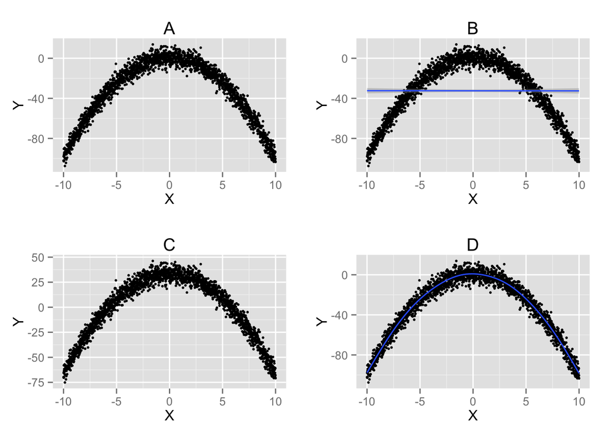

어떻게 데이터에 곡선을 적합시킬 수 있을까?  
원 입력값에 대한 비선형 함수를 새로운 입력값으로 만들어 사용 (ex. 원 입력 x를 제곱한 값을 새로운 입력값으로)  
아래 그림과 같이 x.squared에 대한 y 그래프를 그려보면 직선 적합이 나온다.  
원래의 비선형 문제를 선형 회귀의 선형성 가정을 실제로 만족하는 새로운 문제로 변환한 것.  
이는 커널 트릭의 기본 개념이기도 하다.

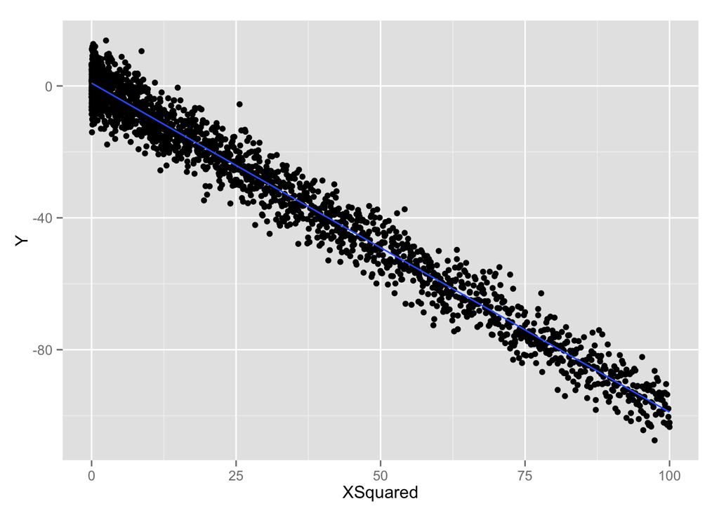

```r
x.squared <- x^2

ggplot(data.frame(XSquared = x.squared, Y = y), aes(x = XSquared, y = Y)) +
  geom_point() +
  geom_smooth(method = 'lm', se = FALSE)
```

예측 품질이 얼마나 좋아졌는지 확인하기 위해 각 선형 회귀의 R^2 값을 계산  
간단한 제곱 변환만으로 분산을 설명하는 정도가 0%에서 97%로 바뀌었다.

```r
summary(lm(y ~ x))$r.squared
```

```
## [1] 2.973e-06
```

```r
summary(lm(y ~ x.squared))$r.squared
```

```
## [1] 0.9706
```

두 변수 사이에 있는 어떤 종류의 관계도 더 복잡한 곡선 형태를 이용해 찾아낼 수 있음이 수학적으로 밝혀졌다.  
이 방법 중 하나가 다항식 회귀(polynomial regression)

다항식 회귀의 유연성이 전적으로 좋은 것만은 아니다.  
데이터에서 찾고자 하는 진짜 패턴 말고 데이터의 잡음 또한 잘 찾아내기 때문

선형 회귀 같은 단순한 도구 대신에 다항식 회귀 같이 더 복잡한 도구를 사용하려 할 때 배워야 할 추가 지식(교차검증, 정규화)에 중점을 두고 설명한다.

#### 다항식 회귀 소개

x와 y의 관계가 직선으로는 도저히 설명이 안 되도록 사인 곡선으로 데이터를 만들면  
단순 선형 회귀 모형이 들어맞지 않을게 분명하다. 한번 단순 선형 모형을 실행해서 성능이 어떤지 볼까?

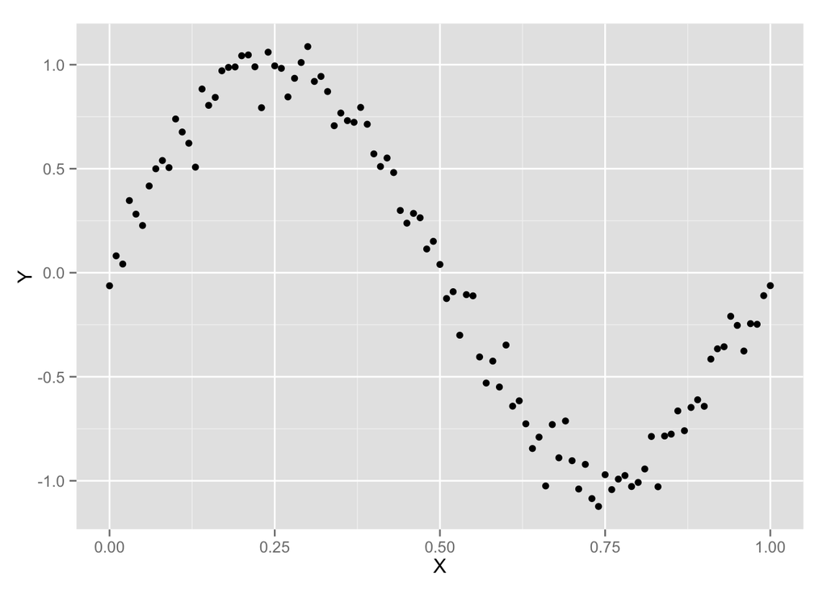

```
##
## Call:
## lm(formula = Y ~ X, data = df)
##
## Residuals:
##     Min      1Q  Median      3Q     Max
## -1.0038 -0.4125 -0.0041  0.4066  0.8587
##
## Coefficients:
##             Estimate Std. Error t value Pr(>|t|)
## (Intercept)   0.9411     0.0906    10.4   <2e-16 ***
## X            -1.8619     0.1565   -11.9   <2e-16 ***
## ---
## Signif. codes:  0 '***' 0.001 '**' 0.01 '*' 0.05 '.' 0.1 ' ' 1
##
## Residual standard error: 0.458 on 99 degrees of freedom
## Multiple R-squared:  0.588,  Adjusted R-squared:  0.584
## F-statistic:  142 on 1 and 99 DF,  p-value: <2e-16
```

단순 선형 회귀 모형이 파형 데이터에는 나쁜 모형이라는 사실에도 불구하고 데이터 분산의 60%가 설명 가능했다.  
좋은 모형은 대략 90% 이상을 설명해야 한다는 것을 알고있지만 이 정도 수준의 적합도를 내는 이유도 궁금하네?

그려보자.  
선형 모형이 아래쪽으로 내려가는 직선으로 사인 곡선의 절반을 찾아냈다.  
하지만 이는 좋은 전략은 아니다. 왜냐하면

- 아래쪽 직선으로 묘사되지 않는 데이터를 체계상으로 무시하기 때문
- 게다가 사인파 곡선이 다음 주기로 확장되면 이 모형의 R^2 값은 0%로 갑자기 수렴해갈 것이다.

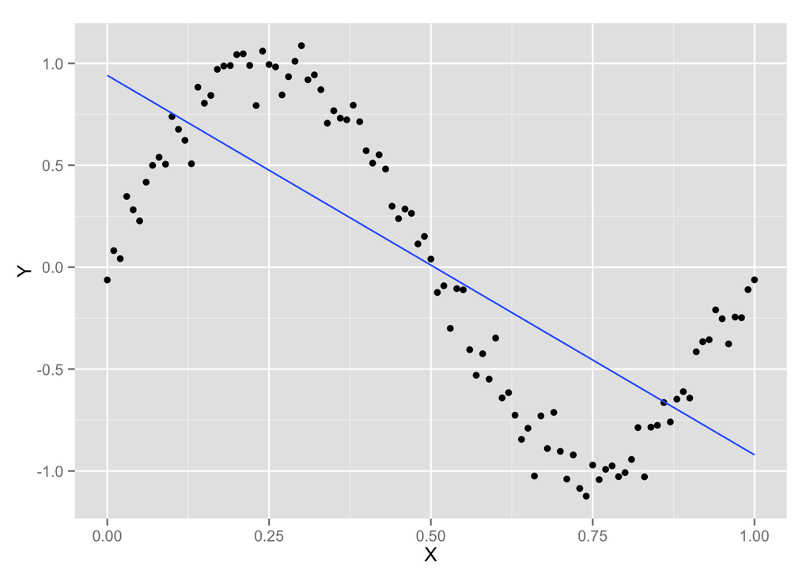

```r
ggplot(data.frame(X = x, Y = y), aes(x = X, y = Y)) +
  geom_point() +
  geom_smooth(method = 'lm', se = FALSE)
```

x의 제곱항, 세제곱항을 같이 넣어서 모형의 재량권을 늘려보면 예측력이 상당히 개선된다. (R^2 60%->97%)

```r
df <- transform(df, X2 = X ^ 2)
df <- transform(df, X3 = X ^ 3)

summary(lm(Y ~ X + X2 + X3, data = df))
```

```
##
## Call:
## lm(formula = Y ~ X + X2 + X3, data = df)
##
## Residuals:
##     Min      1Q  Median      3Q     Max
## -0.3233 -0.0854  0.0065  0.0832  0.2024
##
## Coefficients:
##             Estimate Std. Error t value Pr(>|t|)
## (Intercept)  -0.1634     0.0443   -3.69  0.00037 ***
## X            11.6784     0.3851   30.32  < 2e-16 ***
## X2          -33.9418     0.8975  -37.82  < 2e-16 ***
## X3           22.5935     0.5898   38.31  < 2e-16 ***
## ---
## Signif. codes:  0 '***' 0.001 '**' 0.01 '*' 0.05 '.' 0.1 ' ' 1
##
## Residual standard error: 0.115 on 97 degrees of freedom
## Multiple R-squared:  0.974,  Adjusted R-squared:  0.974
## F-statistic: 1.24e+03 on 3 and 97 DF,  p-value: <2e-16
```

이론상 x의 고차항을 계속 추가하는 논리를 따르지 않을 이유가 없어 보인다.  
하지만 고차항을 계속 추가하면 결국 데이터 점보다 입력값이 더 많게 되고  
그 말은 이론상 데이터 적합을 완벽하게 할 수 있다는 뜻이므로 보통 문제가 된다.

더 미묘한 문제는 특이점(singularity) 문제  
(cf. singular matrix : http://www.ktword.co.kr/abbr_view.php?m_temp1=5051&m_search=%C5%B8)  
데이터에 추가한 새로운 열이 원본 열과 값 차이가 거의 나지 않아서 더이상 lm이 작동하지 않는 문제이다.  
(참고 : 다중공선성 - http://ai-times.tistory.com/268)

```r
df <- transform(df, X4 = X ^ 4)
df <- transform(df, X5 = X ^ 5)
df <- transform(df, X6 = X ^ 6)
df <- transform(df, X7 = X ^ 7)
df <- transform(df, X8 = X ^ 8)
df <- transform(df, X9 = X ^ 9)
df <- transform(df, X10 = X ^ 10)
df <- transform(df, X11 = X ^ 11)
df <- transform(df, X12 = X ^ 12)
df <- transform(df, X13 = X ^ 13)
df <- transform(df, X14 = X ^ 14)
df <- transform(df, X15 = X ^ 15)

summary(lm(Y ~ X + X2 + X3 + X4 + X5 + X6 + X7 + X8 + X9 + X10 + X11 + X12 + X13 + X14,
           data = df))
```

```
##
## Call:
## lm(formula = Y ~ X + X2 + X3 + X4 + X5 + X6 + X7 + X8 + X9 +
##     X10 + X11 + X12 + X13 + X14, data = df)
##
## Residuals:
##      Min       1Q   Median       3Q      Max
## -0.24266 -0.03818  0.00277  0.05248  0.21092
##
## Coefficients: (1 not defined because of singularities)
##              Estimate Std. Error t value Pr(>|t|)
## (Intercept) -6.91e-02   8.41e-02   -0.82     0.41
## X            1.49e+01   1.06e+01    1.42     0.16
## X2          -2.61e+02   4.28e+02   -0.61     0.54
## X3           3.76e+03   7.86e+03    0.48     0.63
## X4          -3.20e+04   8.02e+04   -0.40     0.69
## X5           1.72e+05   5.05e+05    0.34     0.73
## X6          -6.23e+05   2.09e+06   -0.30     0.77
## X7           1.59e+06   5.88e+06    0.27     0.79
## X8          -2.89e+06   1.15e+07   -0.25     0.80
## X9           3.75e+06   1.54e+07    0.24     0.81
## X10         -3.40e+06   1.41e+07   -0.24     0.81
## X11          2.04e+06   8.38e+06    0.24     0.81
## X12         -7.28e+05   2.91e+06   -0.25     0.80
## X13          1.17e+05   4.47e+05    0.26     0.79
## X14                NA         NA      NA       NA
##
## Residual standard error: 0.0908 on 87 degrees of freedom
## Multiple R-squared:  0.986,  Adjusted R-squared:  0.984
## F-statistic:  465 on 13 and 87 DF,  p-value: <2e-16
```

새로 추가한 열의 차수가 점점 높아질수록 원래 열과의 상관관계가 너무 높아져서  
선형 회귀 알고리즘이 제대로 작동하지 않아 모든 열에 대한 계수를 따로 구할 수 없게 된다는 점이다.

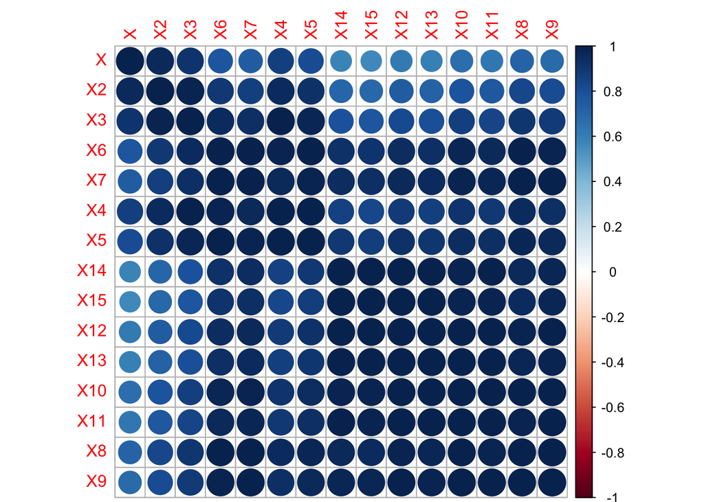

```r
library(corrplot)

corrplot(cor(df[-2]), order = "hclust")
```

해결책 :  
x의 고차항을 단순히 더하지 말고 x의 거듭제곱 항처럼 작동하는 더 복잡한 변수를 추가하되,  
x와 x^2항과 같은 식으로 상관관계가 없도록 변수를 조절하는 것이다. (참고 1)

이런 x의 거듭제곱 항의 변형을 직교 다항식(orthogonal polynomial)이라 하며  
R의 poly 함수로 쉽게 생성 가능하고 lm을 실행할 때 특이점 문제가 발생하지 않는다.

실제로 poly 함수를 사용하여 lm 출력 결과를 살펴보면 표현력이 많이 올라간 것을 확인할 수 있다.

```r
summary(lm(Y ~ poly(X, degree = 14), data = df))
```

```
##
## Call:
## lm(formula = Y ~ poly(X, degree = 14), data = df)
##
## Residuals:
##      Min       1Q   Median       3Q      Max
## -0.23256 -0.04293  0.00216  0.05102  0.20996
##
## Coefficients:
##                        Estimate Std. Error t value Pr(>|t|)
## (Intercept)             0.01017    0.00904    1.12    0.264
## poly(X, degree = 14)1  -5.45536    0.09083  -60.06  < 2e-16 ***
## poly(X, degree = 14)2  -0.03939    0.09083   -0.43    0.666
## poly(X, degree = 14)3   4.41805    0.09083   48.64  < 2e-16 ***
## poly(X, degree = 14)4  -0.04797    0.09083   -0.53    0.599
## poly(X, degree = 14)5  -0.70645    0.09083   -7.78  1.5e-11 ***
## poly(X, degree = 14)6  -0.20422    0.09083   -2.25    0.027 *
## poly(X, degree = 14)7  -0.05134    0.09083   -0.57    0.573
## poly(X, degree = 14)8  -0.03100    0.09083   -0.34    0.734
## poly(X, degree = 14)9   0.07723    0.09083    0.85    0.398
## poly(X, degree = 14)10  0.04809    0.09083    0.53    0.598
## poly(X, degree = 14)11  0.12999    0.09083    1.43    0.156
## poly(X, degree = 14)12  0.02473    0.09083    0.27    0.786
## poly(X, degree = 14)13  0.02371    0.09083    0.26    0.795
## poly(X, degree = 14)14  0.08791    0.09083    0.97    0.336
## ---
## Signif. codes:  0 '***' 0.001 '**' 0.01 '*' 0.05 '.' 0.1 ' ' 1
##
## Residual standard error: 0.0908 on 86 degrees of freedom
## Multiple R-squared:  0.986,  Adjusted R-squared:  0.984
## F-statistic:  432 on 14 and 86 DF,  p-value: <2e-16
```

하지만 이 사실이 꼭 좋은 것만은 아니다 poly로 추가된 거듭제곱 항이 어떤 문제를 일으키는지 살펴보기 위해  
degree 인수를 1, 3, 15, 25로 증가시키면서 poly가 생성한 모형의 모양을 살펴보자.  
degree가 커질 수록 더이상 파형을 닮지 않고 모양이 왜곡되는게 뚜렷히 보인다.  
데이터가 감당 못할 정도로 모형이 너무 강력해진다는 점이 문제이다 => 과대적합(overfitting) 문제

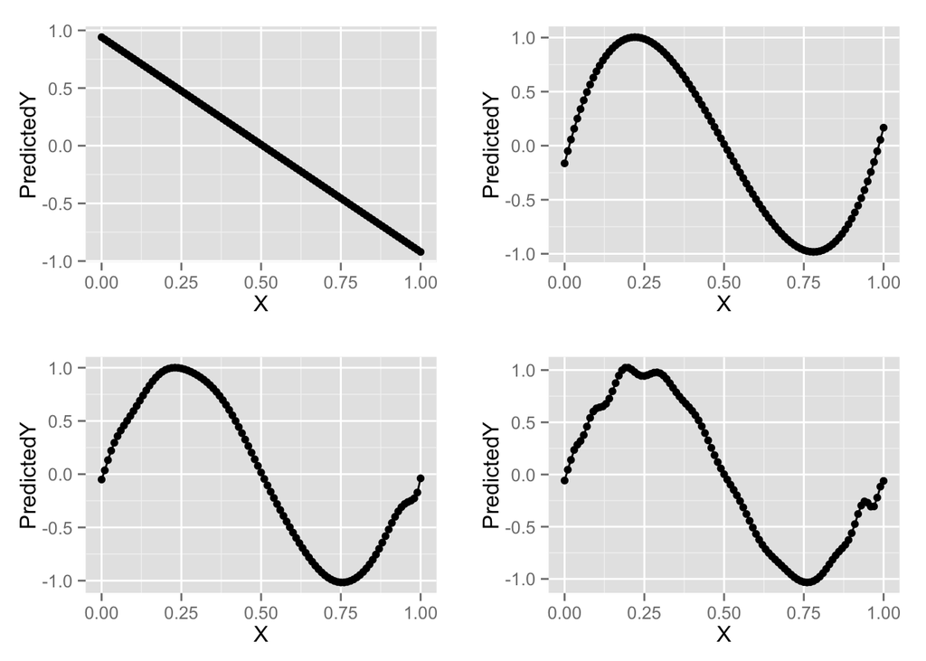

### 과대적합을 막는 방법

해결책 : 교차검증(cross-validation)과 정규화(regularization)

#### 교차검증

앞에서 모형이 데이터에 내재한 진짜 신호 대신 잡음에 적합될 경우에 과대적합이라고 했다.  
하지만 참 값이 뭔지 모른다면 과대적합에 가까워지는지 멀어지는지 어떻게 알 수 있을까?  
비결은 참 값의 의미를 명확히 하는 것. 예측 모형은 그 목적상 미래의 데이터에 대한 예측이 정확할 때 참 값에 가깝다.  
보통은 미래의 데이터를 미리 구할 수는 없으므로 과거 데이터를 두 부분으로 나누어서 미래의 데이터를 가상으로 만든다.  
이런 전략을 통해 아직 접하지 않은 데이터에 모형을 검증하는 과정을 완전히 현실적으로 모의 실험할 수 있다.

교차검증이란 과거 데이터의 일부분을 떼어 놓고 모형을 적합시킴으로써  
미래 데이터에 모형을 검증하는 과정을 모의 실험하는 작업을 뜻한다.

사인 곡선 예제에 교차검증을 적용해서 적당한 다항식 회귀 차수를 찾아보자.

1. 우선 모형을 적합시킬 학습 데이터와 모형의 성능을 시험할 검증 데이터로 나눈다.  
   여기서는 5:5로 나누었지만 실제로 교차검증을 적용할 때는 학습 데이터의 비중을 높이는게(80% 정도) 좋다.  
   모형 적합에 더 많은 데이터를 쓸수록 모형 성능이 더 나아지는 경향이 있기 때문이다.
2. 각 데이터 세트가 특정 규칙에 따라 분리되지 않아야 하므로 데이터를 분리할 때는 항상 무작위 방법을 쓰도록 한다.  
   예를 들어 작은 값만 학습 데이터세트에 넣고 큰 값은 검증 데이터세트에 넣는다면 문제가 생길 것이다)
3. 다항식의 차수를 바꾸어가며 training.df에 있는 데이터에 대해 각 차수의 다항식 회귀 모형을 적합시키고  
   training.df와 test.df 모두에 대해 성능 평가 결과를 저장한 후 그래프로 그려본다.

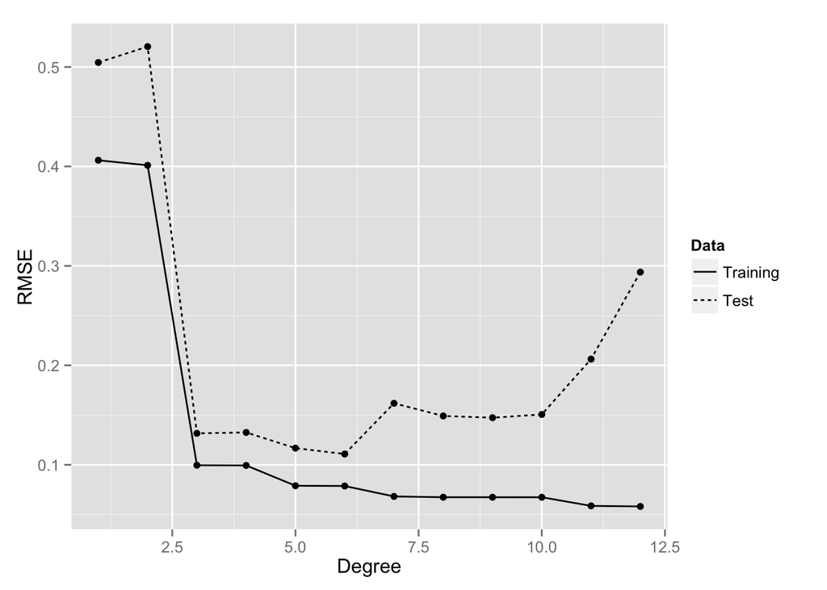

```r
n <- length(x)

# 무작위 방법으로 학습 데이터, 검증 데이터 분리한다.
indices <- sort(sample(1:n, round(0.5 * n)))

training.x <- x[indices]
training.y <- y[indices]

test.x <- x[-indices]
test.y <- y[-indices]

training.df <- data.frame(X = training.x, Y = training.y)
test.df <- data.frame(X = test.x, Y = test.y)

# 모형의 성능을 측정하는 데는 RMSE를 사용
rmse <- function(y, h)
{
  return(sqrt(mean((y - h) ^ 2)))
}

# 다항식의 차수를 1~12까지 바꾸어가며 다항식 회귀 모형을 시험해보고
# 가장 좋은 경우를 찾는다.
performance <- data.frame()
for (d in 1:12) {
  poly.fit <- lm(Y ~ poly(X, degree = d), data = training.df)

  # 트레이닝 데이터의 성능
  performance <- rbind(performance,
                       data.frame(Degree = d,
                                  Data = 'Training',
                                  RMSE = rmse(training.y, predict(poly.fit))))
  # 테스트 데이터의 성능
  performance <- rbind(performance,
                       data.frame(Degree = d,
                                  Data = 'Test',
                                  RMSE = rmse(test.y, predict(poly.fit,
                                                              newdata = test.df))))
}

ggplot(performance, aes(x = Degree, y = RMSE, linetype = Data)) +
  geom_point() +
  geom_line()
```

결과 분석

- 검증 데이터에 대해서 중간 차수가 가장 좋은 성능을 보이는 것이 뚜렷하다.
- 차수가 낮은 경우, 모형이 데이터의 실제 패턴을 찾지 못해서 training/test 데이터 모두 예측 성능이 무척 떨어진다.  
  이렇게 모형이 너무 단순해서 학습 데이터에도 잘 맞지 않는 경우는 과소적합(underfitting)이라 부른다.
- 차수가 큰 경우, 모형의 예측 성능이 점점 나빠지는 현상이 보인다.  
  검증 데이터에는 없지만 학습 데이터에 나타나는 우연한 굴곡에 모형이 적합되기 때문에 발생한다. => 과대적합  
  다르게 생각하면 오른쪽으로 갈수록 학습 세트(상승)와 검증 세트(하락)의 성능 차이가 점점 벌어지는 경우라고 볼 수 있다.
- 과소적합도 아니고 과대적합도 아닌 중간점은 교차검증 없이는 찾아내기 무척 어렵다.

#### 정규화

하고자 하는 것 : 복잡도를 올리지 않으면서 최대한 모형을 학습 데이터에 맞춘다.  
말하자면 모형 적합도와 복잡도 사이에 상반관계(trade-off)를 만들어서,  
더 잘 맞는 더 복잡한 모형 vs. 덜 맞는 더 단순한 모형 사이에서 선택을 하는 것  
이런 상반관계가 모형이 학습 데이터의 잡음에 맞춰지지 않도록 막음으로써 결과적으로 과대적합이 방지된다.

glmnet 패키지에는 정규화로 선형 모형을 적합시키는 glmnet 함수가 있다.  
glmnet을 호출하면 가능한 정규화 전체 집합을 얻게 된다.  
결과 목록 제일 윗부분은 가장 강한 정규화를, 가장 아랫부분은 가장 약한 정규화를 말한다.

```r
x <- as.matrix(cbind(x,rev(x)))

library('glmnet')

res <- glmnet(x, y)
head(data.frame(res[c("df", "dev.ratio", "lambda")])); tail(data.frame(res[c("df", "dev.ratio", "lambda")]))
```

```
##   df dev.ratio lambda
## 1  0   0.00000 0.5428
## 2  1   0.09991 0.4946
## 3  1   0.18287 0.4507
## 4  1   0.25173 0.4106
## 5  1   0.30891 0.3742
## 6  1   0.35638 0.3409
```

```
##    df dev.ratio   lambda
## 50  1    0.5884 0.005687
## 51  1    0.5884 0.005182
## 52  1    0.5884 0.004721
## 53  1    0.5885 0.004302
## 54  1    0.5885 0.003920
## 55  1    0.5885 0.003571
```

결과 분석

- Df는 0이 아닌 계수의 수를 뜻한다. 절편은 포함되지 않음
- %Dev는 기본적으로 이 모형의 R^2 값이다.
- Lambda는 가장 중요한 정보. 정규화 알고리즘의 인수로 모형이 얼마나 복잡해질 수 있는지 조정하는 역할 수행

lambda :  
람다가 매우 크면 모형의 복잡도에 크게 불이익을 준다는 뜻으로, 모든 계수가 0에 가까워지게 된다.  
람다가 매우 작으면 복잡도가 늘어나는데 별 불이익을 주지 않는다는 뜻이다.  
람다값은 줄이면 정규화가 점점 약해지다가 람다가 0이 되면 정규화 없이 lm을 이용해서 선형 회귀를 한 결과와 동일한 결과를 얻는다.

이 두 극단 사이 어느 람다 값에서 가장 좋은 모형이 나오게 되는지 찾기 위해 교차검증을 사용한다.

1. 일단 차수를 10과 같이 큰 값으로 설정하고
2. 람다 값을 변경하면서 모형을 학습 세트에 맞추고
3. 분리해 둔 검증 세트에 대해 모형의 성능을 평가한다.
4. 가장 좋은 성능을 내는 Lambda 값 찾기

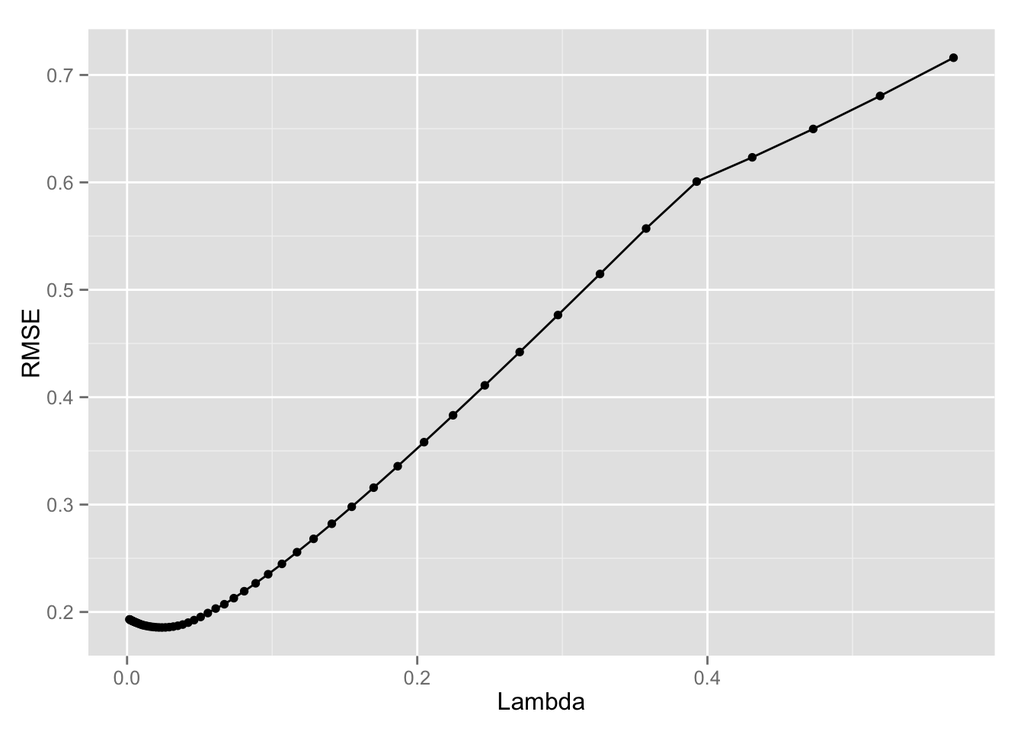

```r
library('glmnet')

# 차수는 10으로 고정, 모든 람다값에 대해 모형을 학습 세트에 맞추고
# (glmnet에서 한 번 적합 과정을 거치면 여러 람다값에 대한 모형 정보들이 저장된다)
glmnet.fit <- with(training.df, glmnet(poly(X, degree = 10), Y))

lambdas <- glmnet.fit$lambda

performance <- data.frame()

# 람다 값을 변경하면서
for (lambda in lambdas)
{
  # 검증 데이터 세트에 대해 모형의 성능 평가
  performance <- rbind(performance,
                       data.frame(Lambda = lambda,
                                  RMSE = rmse(test.y,
                                              with(test.df,
                                                   predict(glmnet.fit,
                                                           poly(X, degree = 10),
                                                           s = lambda)))))
}

# 그래프를 그려서 새로운 데이터에 대해 가장 좋은 성능을 보이는 람다값이 무엇인지 확인
ggplot(performance, aes(x = Lambda, y = RMSE)) +
  geom_point() +
  geom_line()
```

```r
best.lambda <- with(performance, Lambda[which(RMSE == min(RMSE))])

glmnet.fit <- with(df, glmnet(poly(X, degree = 10), Y))

coef(glmnet.fit, s = best.lambda)
```

```
## 11 x 1 sparse Matrix of class "dgCMatrix"
##                    1
## (Intercept)  0.01017
## 1           -5.21326
## 2            .
## 3            4.17595
## 4            .
## 5           -0.46435
## 6            .
## 7            .
## 8            .
## 9            .
## 10           .
```

### 텍스트 회귀

#### 선형 회귀 분석

정규화를 활용할 만한 흥미로운 주제 중 하나는 텍스트를 이용해 연속적인 출력값을 예측하는 일이다.  
(예를 들어 기업 공시 정보를 바탕으로 주가의 변동성을 예측하는 문제)  
텍스트를 회귀 입력값으로 쓸 때는 관측(문서)에 비해 입력(단어)이 훨씬 많은 경우가 대부분  
데이터 세트에서 행보다 열이 더 많기 때문에 정규화를 하지 않는 선형 회귀 모형은 항상 과대적합이 된다.

오라일리가 출판사의 베스트셀러 100위 책들의 상대적 인기도를 책 뒷 장의 소개글만으로 예측하는 문제를 다뤄보자.

1. oreilly.csv 파일을 읽어들여서 분석에 적당한 형태로 전처리 수행

```r
ranks <- read.csv(file.path('data', 'oreilly.csv'),
                  stringsAsFactors = FALSE)

library('tm')

documents <- data.frame(Text = ranks$Long.Desc.)
row.names(documents) <- 1:nrow(documents)

corpus <- Corpus(DataframeSource(documents))
corpus <- tm_map(corpus, stripWhitespace)
corpus <- tm_map(corpus,  content_transformer(tolower))
corpus <- tm_map(corpus, removeWords, stopwords('english'))

dtm <- DocumentTermMatrix(corpus)

x <- as.matrix(dtm)
y <- rev(1:100)
```

2. 람다값을 바꾸어 가며 분리한 검증 데이터에 대해 가장 좋은 결과가 나오는 값을 찾는다.  
   다양한 람다값을 설정하고 데이터를 학습 세트와 검증 세트로 50번 나누어 각 사례마다 모형의 성능을 평가한다.

```r
performance <- data.frame()

for (lambda in c(0.1, 0.25, 0.5, 1, 2, 5))
{
  for (i in 1:50)
  {
    indices <- sample(1:100, 80)

    training.x <- x[indices, ]
    training.y <- y[indices]

    test.x <- x[-indices, ]
    test.y <- y[-indices]

    glm.fit <- glmnet(training.x, training.y)

    predicted.y <- predict(glm.fit, test.x, s = lambda)

    rmse <- sqrt(mean((predicted.y - test.y) ^ 2))

    performance <- rbind(performance,
                         data.frame(Lambda = lambda,
                                    Iteration = i,
                                    RMSE = rmse))
  }
}
```

3. 시각화하여 어떤 모형이 가장 좋은지 비교해본다.

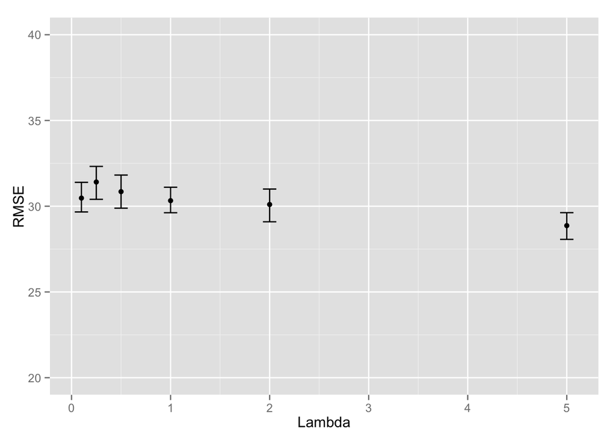

```r
library(Hmisc)

ggplot(performance, aes(x = Lambda, y = RMSE)) +
  stat_summary(fun.data = 'mean_cl_boot', geom = 'errorbar') +
  stat_summary(fun.data = 'mean_cl_boot', geom = 'point') + ylim(20, 40)
```

결과 분석 : 실패!  
람다값이 높아지면 모형 성능도 점점 좋아진다.  
결국 절편뿐이 모형으로 수렴하게 되는데 절편뿐인 모형은 아무런 텍스트 데이터도 사용하지 않는다.  
간단히 말해 텍스트 회귀를 통해 아무런 신호도 찾지 못했다는 뜻이고 모델 검증 과정에서 모두 잡음으로 밝혀졌다.  
=> 책 뒷 표지의 소개글을 어떻게 써야 책이 잘 팔릴지 알 수 없다는 뜻이다.

> 데이터 안에 답이 없을 수도 있다. 데이터가 있고 답을 찾고자 하는 열망이 있더라도  
> 주어진 데이터에서 합리적인 답을 찾으리라는 보장은 없다. - 존 튜키(John Tukey)

#### 로지스틱 회귀 분석

아직은 이 데이터를 포기하지 말고 회귀 문제를 분류 문제로 전환해보자.  
문제를 더 간단히 바꾸어 수많은 순위 값 중에 하나를 예측하는 대신 어떤 책이 50위 안에 드는지를 예측해보자.  
이 구분은 정말 범위가 넓고 단순하므로 작은 양의 데이터로도 쉽게 신호 추출이 될 것으로 예상된다.

사실 로지스틱 회귀는 한 항목이 두 분류 중에 하나에 속할 확률을 예측하는 일종의 회귀 알고리즘이다.  
그런데 확률은 항상 0~1 사이 값이므로, 0.5를 문턱값으로 설정하면 로지스틱 회귀가 분류 알고리즘이 된다.  
출력값이 0에서 1사이라는 사실을 제외하면 본질적으로 로지스틱 회귀는 선형 회귀와 동일하다.  
유일한 차이점은 분류 예측을 하기 위해 출력에 문턱값을 적용한다는 점이다.

데이터 세트에 분류 레이블을 추가하고 로지스틱 회귀를 적용한 결과를 확인하자.  
선형 회귀와 차이점은 오로지 family라는 추가 인수를 설정했다는 점으로 이 인수는 오차 종류를 조정한다.  
선형회귀는 오차가 가우스분포를 따른다고 가정하는 반면, 로지스틱 회귀는 이항분포(binomial distribution)라고 가정한다.  
이항 분포는 오차가 모두 0 아니면 1이 되며, 이는 분류에 적합한 특성이다. (참고 2)

```r
y <- rep(c(1, 0), each = 50)

regularized.fit <- glmnet(x, y, family = 'binomial')
```

predict 함수를 이용해서 모형의 예측 결과가 어떤지 확인하자.  
예측값이 0이나 1이기를 바랐지만, 출력 결과를 보면 양수와 음수가 섞여있다.

```r
predict(regularized.fit, newx = x, s = 0.001)
```

```
##          1
## 1    4.574
## 2    5.342
## 3    4.668
## 4    5.311
## 5    4.869
## 6    5.334
## 7    4.488
## 8    4.463
## 9    5.352
## 10   4.793
## 11   5.352
## 12   4.483
## 13   5.356
## 14   6.971
```

[output cut: 86 more lines]

분류문제로 바꾸기 위해 가능한 2가지 작업

1. 문턱값을 0으로 하고 ifelse 함수로 0/1 예측치를 만드는 방법

```r
res <- ifelse(predict(regularized.fit, newx = x, s = 0.001) > 0, 1, 0)
head(res); tail(res)
```

```
##   1
## 1 1
## 2 1
## 3 1
## 4 1
## 5 1
## 6 1
```

```
##     1
## 95  0
## 96  0
## 97  0
## 98  0
## 99  0
## 100 0
```

2. 예측값을 해석하기 더 쉬운 확률값으로 바꾸는 방법 (0.5를 문턱값으로 0/1 예측치 생성 작업 필요)

```r
library('boot')

# 로지스틱 회귀에서 출력을 확률로 바꾸려면, 로짓(logit) 역함수로 변환해줘야 한다.
res <- inv.logit(predict(regularized.fit, newx = x, s = 0.001))
head(res); tail(res)
```

```
##        1
## 1 0.9898
## 2 0.9952
## 3 0.9907
## 4 0.9951
## 5 0.9924
## 6 0.9952
```

```
##            1
## 95  0.007309
## 96  0.006863
## 97  0.004781
## 98  0.003929
## 99  0.002386
## 100 0.006411
```

이제 얼마나 잘 분류되는지 확인하자.  
달라진 점은 얼마 없다.

- glmnet에서 이항오차를 쓴 점
- 로지스틱 결과값을 0/1 예측치로 바꾸는 문턱값 설정
- RMSE 대신 오차율을 모형 성능 측도로 사용한 점
- 효율을 위해서 데이터 분리 루프와 람다 루프 순서 바꿈

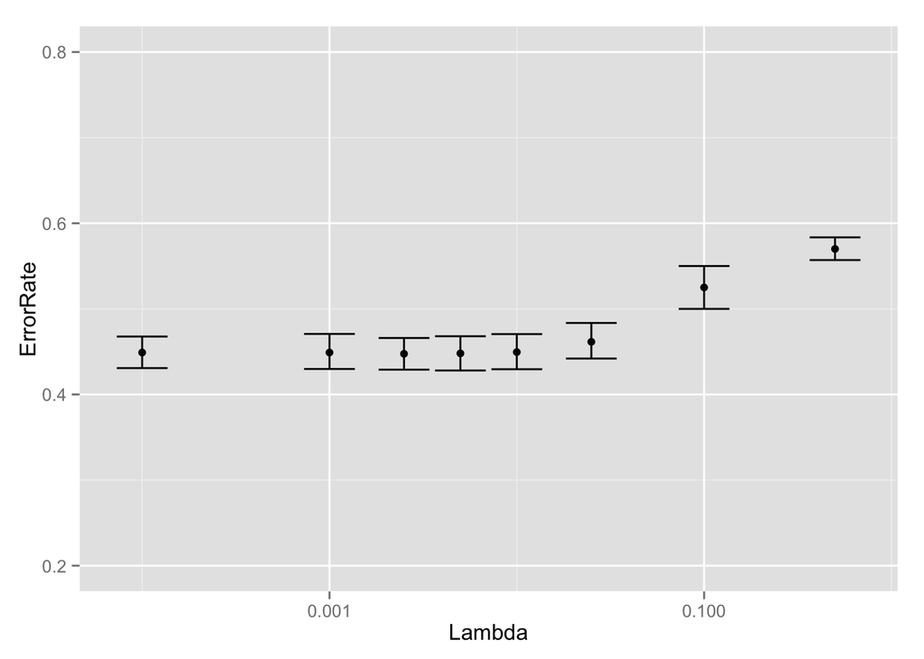

```r
set.seed(1)

performance <- data.frame()

for (i in 1:100)
{
  indices <- sample(1:100, 80)

  training.x <- x[indices, ]
  training.y <- y[indices]

  test.x <- x[-indices, ]
  test.y <- y[-indices]

  for (lambda in c(0.0001, 0.001, 0.0025, 0.005, 0.01, 0.025, 0.5, 0.1))
  {
    glm.fit <- glmnet(training.x, training.y, family = 'binomial')

    predicted.y <- ifelse(predict(glm.fit, test.x, s = lambda) > 0, 1, 0)

    error.rate <- mean(predicted.y != test.y)

    performance <- rbind(performance,
                         data.frame(Lambda = lambda,
                                    Iteration = i,
                                    ErrorRate = error.rate))
  }
}

# 람다에 따른 오차율을 그래프로 그려보자.
ggplot(performance, aes(x = Lambda, y = ErrorRate)) +
  stat_summary(fun.data = 'mean_cl_boot', geom = 'errorbar') +
  stat_summary(fun.data = 'mean_cl_boot', geom = 'point') +
  scale_x_log10() + ylim(0.2, 0.8)
```

잘 바꿨음.  
람다값에 따라 50위권 내 책을 예측하는 성능이 우연보다 더 나은 경우가 있다.  
이 데이터의 분량이 정교한 순위 예측 회귀모형에는 충분하지 않지만,  
50위권 내 여부에 따라 분류하는 더 단순한 이항모형에는 충분하다는 게 밝혀졌다.

교훈 :  
* 정규화로 더 좋은 성능의 더 단순한 모형 찾음  
* 회귀 모형에 더 단순한 이항분리를 사용하여 더 좋은 성능 보임

[figure not shown]

‘’’참고 1’’’ poly 함수가 다항식을 만들 때 어떻게 직교성을 부여하는지?

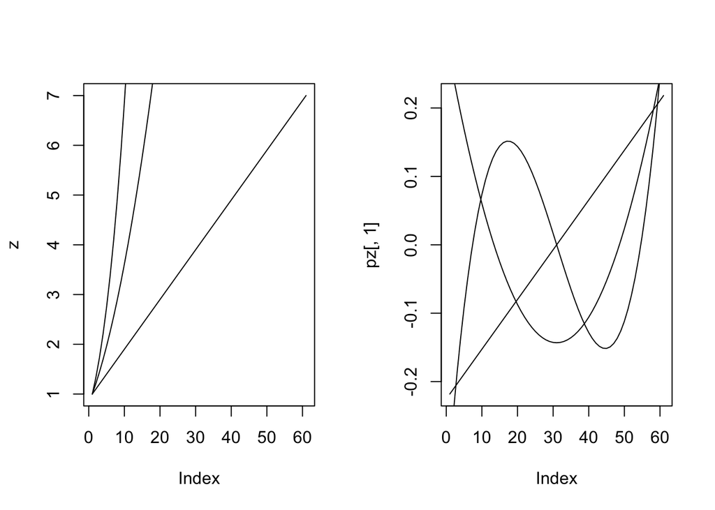

```r
opar <- par ( mfrow = c (1 , 2) )

# x <- seq(0, 1, by = 0.01)
# z <- sin(2 * pi * x) + rnorm(length(x), 0, 0.1)
z <- seq(1, 7, by=0.1)
plot(z, type="l")
lines(z^2)
lines(z^3)

pz <- poly(z, degree=3)
plot(pz[,1], type="l")
lines(pz[,2])
lines(pz[,3])
```

직교성 처리하지 않게 하려면 `poly(z, degree=3, raw=T)`와 같이 raw=TRUE 옵션을 주면 된다.

poly 관련 링크들 참조

- http://stackoverflow.com/questions/17457884/using-lmpoly-to-get-formula-coeff
- http://stackoverflow.com/questions/3822535/fitting-polynomial-model-to-data-in-r
- http://mathoverflow.net/questions/38864/visualizing-orthogonal-polynomials
- http://stats.stackexchange.com/questions/31204/why-do-i-get-wildly-different-results-for-polyraw-t-vs-poly

‘’’참고 2’’’ 어떤 시행을 했을 때 특정 사건이 일어날 확률을 p, 일어나지 않을 확률을 1-p라고 하고 각각의 시행들이 독립적이라고 하자.  
시행을 n번 반복했을 때 그 사건이 k번 일어날 확률은 $\binom{n}{k}p^k(1-p)^{n-k}$이 되며 이 확률분포를 이항분포라 한다.